# BUSN 32100 Data Analysis with R and Python

# Individual Homework 4

Name:

Collaborated with:

## Instructions:

It is recommended that you collaborate with your classmates on this assignment. However, you must type your own code and submit your source file in either `.html` or `.ipynb` format on Canvas. In some cases, a incomplete code is given to guide you in the right direction. However, you will need to fill in the blanks in order to run the code block.

## UN population data

We take a look here at the UN's [population data](http://esa.un.org/unpd/wpp/Download/Standard/Population/): life expectancy, fertility (the word we use for births), and mortality (deaths). Explore the website, it's filled with interesting data. There are other sources that cover longer time periods, and for some countries you can get detailed data on specific things (causes of death, for example).

## Fertility: aka birth rates

Here we look at the fertility using the [UN source](http://esa.un.org/unpd/wpp/Download/Standard/Fertility/). We look at the total fertility. What we want is a plot that have the year ranges(`TimePeriod`) on the x-axis and the fertility rates on the y-axis, with each country represented by each line. Let's take a look at the data first.

**Question 1a** The csv file is located at `https://raw.githubusercontent.com/BUSN32100/data_files/master/UN_fertility_rates.csv`. Read the file into a new dataframe. Then select data for **4 countries** from **4 different continents** and rename this data frame `four_countries`

```python
#import packages
import numpy as np
import pandas as pd
import matplotlib.pyplot as plt
import statsmodels.formula.api as smf
```

```python
# read in the file
un = pd.read_csv('https://raw.githubusercontent.com/BUSN32100/data_files/master/UN_fertility_rates.csv').set_index('TimePeriod')
un
```

| TimePeriod | Burundi | Comoros | Djibouti | Eritrea | Ethiopia | Kenya | Madagascar | Malawi | Mauritius | Mayotte | ... | Spain | Austria | Belgium | France | Germany | Luxembourg | Netherlands | Switzerland | Canada | United States of America |
| --- | --- | --- | --- | --- | --- | --- | --- | --- | --- | --- | --- | --- | --- | --- | --- | --- | --- | --- | --- | --- | --- |
| 1950-1955 | 6.801 | 6.000 | 6.3120 | 6.965 | 7.1696 | 7.481 | 7.300 | 6.8500 | 5.8950 | 7.9100 | ... | 2.5300 | 2.1046 | 2.3650 | 2.7632 | 2.1280 | 1.9800 | 3.0524 | 2.3101 | 3.645 | 3.3110 |
| 1955-1960 | 6.857 | 6.601 | 6.3874 | 6.965 | 6.9023 | 7.785 | 7.300 | 6.9000 | 5.8950 | 7.9100 | ... | 2.7000 | 2.5652 | 2.4960 | 2.7031 | 2.2740 | 2.2300 | 3.0974 | 2.3912 | 3.882 | 3.5821 |
| 1960-1965 | 7.050 | 6.909 | 6.5470 | 6.815 | 6.8972 | 8.065 | 7.300 | 7.0037 | 6.1950 | 7.9100 | ... | 2.8100 | 2.7777 | 2.6466 | 2.8451 | 2.4736 | 2.3950 | 3.1657 | 2.5972 | 3.675 | 3.2336 |
| 1965-1970 | 7.230 | 7.050 | 6.7070 | 6.699 | 6.8691 | 8.110 | 7.300 | 7.2038 | 4.6100 | 7.9100 | ... | 2.8400 | 2.5689 | 2.3881 | 2.6518 | 2.3605 | 2.1920 | 2.7949 | 2.3551 | 2.610 | 2.5434 |
| 1970-1975 | 7.260 | 7.050 | 6.8450 | 6.620 | 7.1038 | 7.990 | 7.200 | 7.4019 | 3.4660 | 7.9100 | ... | 2.8500 | 2.0369 | 2.0143 | 2.3081 | 1.7084 | 1.7220 | 2.1001 | 1.8714 | 1.976 | 2.0294 |
| 1975-1980 | 7.400 | 7.050 | 6.6440 | 6.620 | 7.1838 | 7.640 | 6.950 | 7.6000 | 3.1050 | 7.9100 | ... | 2.5500 | 1.6513 | 1.7049 | 1.8608 | 1.5080 | 1.4860 | 1.5982 | 1.5388 | 1.734 | 1.7718 |
| 1980-1985 | 7.380 | 7.050 | 6.4500 | 6.700 | 7.4247 | 7.216 | 6.500 | 7.6000 | 2.3015 | 7.3504 | ... | 1.8800 | 1.5957 | 1.5959 | 1.8646 | 1.4637 | 1.4650 | 1.5149 | 1.5390 | 1.634 | 1.8044 |
| 1985-1990 | 7.460 | 6.700 | 6.1810 | 6.600 | 7.3673 | 6.538 | 6.250 | 7.2500 | 2.3118 | 6.7270 | ... | 1.4600 | 1.4480 | 1.5600 | 1.8043 | 1.4295 | 1.4690 | 1.5546 | 1.5470 | 1.616 | 1.9146 |
| 1990-1995 | 7.300 | 6.100 | 5.8500 | 6.300 | 7.0888 | 5.650 | 6.100 | 6.5000 | 2.2465 | 5.2500 | ... | 1.2800 | 1.4837 | 1.6119 | 1.7145 | 1.3007 | 1.6630 | 1.5923 | 1.5390 | 1.694 | 2.0297 |
| 1995-2000 | 7.050 | 5.600 | 4.8120 | 5.600 | 6.8335 | 5.350 | 5.801 | 6.2000 | 2.0332 | 5.0800 | ... | 1.1870 | 1.3879 | 1.6041 | 1.7616 | 1.3456 | 1.7213 | 1.5991 | 1.4840 | 1.562 | 1.9965 |
| 2000-2005 | 6.770 | 5.200 | 4.2100 | 5.100 | 6.1800 | 5.000 | 5.278 | 6.0000 | 1.9335 | 4.8000 | ... | 1.2773 | 1.3796 | 1.6836 | 1.8819 | 1.3513 | 1.6540 | 1.7396 | 1.4079 | 1.516 | 2.0420 |

11 rows × 201 columns

```python
# select countries
four_countries = un[['United States of America','Japan','Germany','Australia']]
four_countries
```

| TimePeriod | United States of America | Japan | Germany | Australia |
| --- | --- | --- | --- | --- |
| 1950-1955 | 3.3110 | 2.960 | 2.1280 | 3.1800 |
| 1955-1960 | 3.5821 | 2.170 | 2.2740 | 3.4060 |
| 1960-1965 | 3.2336 | 2.030 | 2.4736 | 3.2740 |
| 1965-1970 | 2.5434 | 2.040 | 2.3605 | 2.8710 |
| 1970-1975 | 2.0294 | 2.134 | 1.7084 | 2.5350 |
| 1975-1980 | 1.7718 | 1.831 | 1.5080 | 1.9890 |
| 1980-1985 | 1.8044 | 1.762 | 1.4637 | 1.9100 |
| 1985-1990 | 1.9146 | 1.650 | 1.4295 | 1.8590 |
| 1990-1995 | 2.0297 | 1.476 | 1.3007 | 1.8628 |
| 1995-2000 | 1.9965 | 1.369 | 1.3456 | 1.7866 |
| 2000-2005 | 2.0420 | 1.298 | 1.3513 | 1.7739 |

**Question 1b** Plot the new data using a line plot. Complete the following

- Change the figure size to width = 7 and height = 4
- Add the title, 'Fertility (births per woman, lifetime)' on the left
- Add a horizontal line by this command `ax.hlines(2.1, -1, 13, linestyles='dashed')`. Note if your axes are not named `ax` change accordingly
- Add a text with this line `ax.text(8.5, 2.4, 'Replacement = 2.1')`

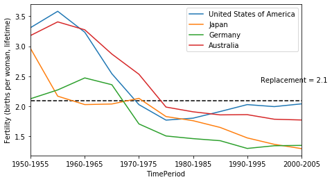

```python
# Your plot here
four_countries.plot(figsize=(7, 4)).set_ylabel("Fertility (births per woman, lifetime)")
ax = plt.gca()
ax.hlines(2.1, -1, 13, linestyles='dashed')
ax.text(8.5, 2.4, 'Replacement = 2.1')
```

**Question 1c** Add other countries you are interested in to the figure. How do they compare to the rest? Add them in the next cell and comment on your findings

```python
# Add a few more countries
four_countries = un[['United States of America','Japan','Germany','Australia','France','Norway','China','Kenya','Zimbabwe']]
four_countries
#When you add developing countries like Kenya and Zimbabwe we have higher but rapidly declining fertility rates. It's worth mentioning that China's fertility rate rapiudly caught up to the developed world in recent years.
```

| TimePeriod | United States of America | Japan | Germany | Australia | France | Norway | China | Kenya | Zimbabwe |
| --- | --- | --- | --- | --- | --- | --- | --- | --- | --- |
| 1950-1955 | 3.3110 | 2.960 | 2.1280 | 3.1800 | 2.7632 | 2.6020 | 6.11 | 7.481 | 6.8000 |
| 1955-1960 | 3.5821 | 2.170 | 2.2740 | 3.4060 | 2.7031 | 2.8370 | 5.48 | 7.785 | 7.0000 |
| 1960-1965 | 3.2336 | 2.030 | 2.4736 | 3.2740 | 2.8451 | 2.8980 | 6.15 | 8.065 | 7.3000 |
| 1965-1970 | 2.5434 | 2.040 | 2.3605 | 2.8710 | 2.6518 | 2.8000 | 6.30 | 8.110 | 7.4000 |
| 1970-1975 | 2.0294 | 2.134 | 1.7084 | 2.5350 | 2.3081 | 2.3500 | 4.85 | 7.990 | 7.4000 |
| 1975-1980 | 1.7718 | 1.831 | 1.5080 | 1.9890 | 1.8608 | 1.8100 | 3.01 | 7.640 | 7.3000 |
| 1980-1985 | 1.8044 | 1.762 | 1.4637 | 1.9100 | 1.8646 | 1.6870 | 2.52 | 7.216 | 6.3018 |
| 1985-1990 | 1.9146 | 1.650 | 1.4295 | 1.8590 | 1.8043 | 1.8000 | 2.73 | 6.538 | 5.3732 |
| 1990-1995 | 2.0297 | 1.476 | 1.3007 | 1.8628 | 1.7145 | 1.8860 | 1.83 | 5.650 | 4.4150 |
| 1995-2000 | 1.9965 | 1.369 | 1.3456 | 1.7866 | 1.7616 | 1.8620 | 1.62 | 5.350 | 3.8850 |
| 2000-2005 | 2.0420 | 1.298 | 1.3513 | 1.7739 | 1.8819 | 1.8061 | 1.61 | 5.000 | 3.7200 |

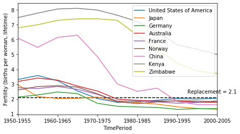

```python
# Your plot here
four_countries.plot(figsize=(7, 4)).set_ylabel("Fertility (births per woman, lifetime)")
ax = plt.gca()
ax.hlines(2.1, -1, 13, linestyles='dashed')
ax.text(8.5, 2.4, 'Replacement = 2.1')
```

## Data transformation

Load the US state unemployment data from Bureau of Labor Statistics

```python
import pandas as pd

unemp = pd.read_csv('https://raw.githubusercontent.com/BUSN32100/data_files/master/unemp.csv', index_col = 0, parse_dates=["Date"])
unemp.head()
```

| Date | Arizona | California | Florida | Illinois | Michigan | New York | Texas |
| --- | --- | --- | --- | --- | --- | --- | --- |
| 2000-01-01 | 4.1 | 5.0 | 3.7 | 4.2 | 3.3 | 4.7 | 4.6 |
| 2000-02-01 | 4.1 | 5.0 | 3.7 | 4.2 | 3.2 | 4.7 | 4.6 |
| 2000-03-01 | 4.0 | 5.0 | 3.7 | 4.3 | 3.2 | 4.6 | 4.5 |
| 2000-04-01 | 4.0 | 5.1 | 3.7 | 4.3 | 3.3 | 4.6 | 4.4 |
| 2000-05-01 | 4.0 | 5.1 | 3.7 | 4.3 | 3.5 | 4.6 | 4.3 |

### Question 2a

What was the maximum unemployment rate across the states in our sample? What state did it happen in? In what month/year was this achieved?

```python
# Your code here
unemp.max()
#The maximum unemployment rate across the states in our sample was 14.6% in Michigan.
```

```
Arizona       10.9
California    12.3
Florida       11.3
Illinois      11.3
Michigan      14.6
New York       8.9
Texas          8.3
dtype: float64
```

```python
unemp[unemp['Michigan'] == 14.6]
#This happened at the height of the great recession in 2009-06-01.
```

| Date | Arizona | California | Florida | Illinois | Michigan | New York | Texas |
| --- | --- | --- | --- | --- | --- | --- | --- |
| 2009-06-01 | 9.9 | 11.2 | 10.5 | 10.4 | 14.6 | 8.4 | 8.0 |

### Question 2b

Imagine that we want to determine whether unemployment was high (> 6.5), medium (4.5 < x <= 6.5), or low (<= 4.5) for each state and each month

Write a Python function that takes a single number as an input and outputs a single string noting if that number is high, medium, or low

```python
# Your code here
def rate(i):
    if(i>6.5):
        st= "high"
        return st
    elif (4.5<i<=6.5):
        st= "medium"
        return st
    else:
        st="low"
        return st
    print("return statement")
```

Pass your function to either `apply` or `applymap` and save the result in a new DataFrame called `unemp_bins`

```python
# Your code here
unemp_bins=unemp.applymap(rate)
unemp_bins
```

| Date | Arizona | California | Florida | Illinois | Michigan | New York | Texas |
| --- | --- | --- | --- | --- | --- | --- | --- |
| 2000-01-01 | low | medium | low | low | low | medium | medium |
| 2000-02-01 | low | medium | low | low | low | medium | medium |
| 2000-03-01 | low | medium | low | low | low | medium | low |
| 2000-04-01 | low | medium | low | low | low | medium | low |
| 2000-05-01 | low | medium | low | low | low | medium | low |
| ... | ... | ... | ... | ... | ... | ... | ... |
| 2017-08-01 | medium | medium | low | medium | medium | medium | low |
| 2017-09-01 | medium | low | low | medium | medium | medium | low |
| 2017-10-01 | medium | low | low | medium | medium | medium | low |
| 2017-11-01 | medium | low | low | medium | medium | medium | low |
| 2017-12-01 | medium | low | low | medium | medium | medium | low |

216 rows × 7 columns

## Question 2c

This question has multiple parts:

Use another transformation on `unemp_bins` to count how many times each state had each of the three classifications.

- Hint 1: Will you need to use `apply` or `applymap` for transformation?
- Hint 2: Try googling “pandas count unique value” or something similar to find the right transformation , and it's NOT `nunique`
- Hint 3: You have three options when `apply`ing this function, you could
  1. pass this function from its package,
  2. write a user defined function
  3. use a `lambda` function

```python
# Your code here
applied = unemp_bins.T.apply(lambda x: x.value_counts(), axis=1)
applied
```

|  | high | low | medium |
| --- | --- | --- | --- |
| Arizona | 75 | 44 | 97 |
| California | 106 | 4 | 106 |
| Florida | 68 | 69 | 79 |
| Illinois | 91 | 19 | 106 |
| Michigan | 142 | 17 | 57 |
| New York | 65 | 22 | 129 |
| Texas | 51 | 58 | 107 |

Construct a horizontal bar chart of the number of occurrences of each level with one bar per state and classification (21 total bars)

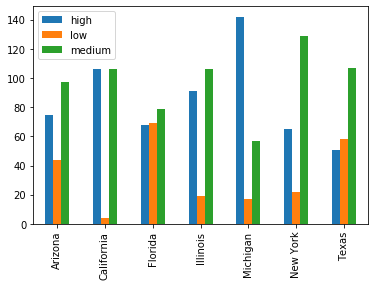

```python
# Your code here
%matplotlib inline
applied.plot.bar()
```

### Question 2d

Repeat Question 3c, but count how many states had each classification in each month. Which month had the most states with high unemployment? What about medium and low?

Hint: you might need to deal with missing values with `fillna()`

```python
# Part 1: Write a Python function to classify unemployment levels
unemp_bins
applied2 = unemp_bins.T.apply(lambda x: x.value_counts(), axis=0).fillna('')
applied2
```

| Date | 2000-01-01 | 2000-02-01 | 2000-03-01 | 2000-04-01 | 2000-05-01 | 2000-06-01 | 2000-07-01 | 2000-08-01 | 2000-09-01 | 2000-10-01 | ... | 2017-03-01 | 2017-04-01 | 2017-05-01 | 2017-06-01 | 2017-07-01 | 2017-08-01 | 2017-09-01 | 2017-10-01 | 2017-11-01 | 2017-12-01 |
| --- | --- | --- | --- | --- | --- | --- | --- | --- | --- | --- | --- | --- | --- | --- | --- | --- | --- | --- | --- | --- | --- |
| high |  |  |  |  |  |  |  |  |  |  | ... |  |  |  |  |  |  |  |  |  |  |
| low | 4 | 4 | 5 | 5 | 5 | 5 | 5 | 6 | 6 | 6 | ... | 1 | 3 | 3 | 3 | 3 | 2 | 3 | 3 | 3 | 3 |
| medium | 3 | 3 | 2 | 2 | 2 | 2 | 2 | 1 | 1 | 1 | ... | 6 | 4 | 4 | 4 | 4 | 5 | 4 | 4 | 4 | 4 |

3 rows × 216 columns

## Time series

A complete list of possible `%`something patterns that are accepted in the `format` argument can be found in the official [Python documentation](https://docs.python.org/3/library/datetime.html#strftime-and-strptime-behavior)

### Question 3a

By referring to table found at the link above, figure out the correct argument to pass as `format` in order to parse the dates in the next three cells below

Test your work by passing your format string to `pd.to_datetime`

```python
christmas_str2 = "2017:12:25"
pd.to_datetime(christmas_str2, format= '%Y:%m:%d')
```

```
Timestamp('2017-12-25 00:00:00')
```

```python
cubs_win = "M:11 D:2 Y:2016 11:47 PM"
pd.to_datetime(cubs_win, format='M:%m D:%d Y:%Y %I:%M %p')
```

```
Timestamp('2016-11-02 23:47:00')
```

```python
america_bday = "America was born on July 4, 1776"
pd.to_datetime(america_bday, format = 'America was born on %B %d, %Y')
```

```
Timestamp('1776-07-04 00:00:00')
```

### Date formatting

We can use the `%`pattern format to have pandas write `datetime` objects as specially formatted strings using the `strftime` (string format time) method

For example

```python
christmas_str = "2018-12-25"
christmas = pd.to_datetime(christmas_str)
christmas.strftime("We love %A %B %d (also written %c)")
```

```
'We love Tuesday December 25 (also written Tue Dec 25 00:00:00 2018)'
```

### Question 3b

Use `pd.to_datetime` to express your birthday as a `datetime` object.

Then use the `strftime` method to write a message of the format:

```
"NAME's birthday is June 10, 1989 (a Saturday)"
```

(where the name and date are replaced by the appropriate values for you)

```python
# your code here
birthday_str = "April 22, 1992"
birthday = pd.to_datetime(birthday_str)
birthday.strftime("Hikaru's birthday is %B %d, %Y")
```

```
"Hikaru's birthday is April 22, 1992"
```

### Question 3c

Imagine that you have access to the [DeLorean time machine](https://en.wikipedia.org/wiki/DeLorean_time_machine) from “Back to the Future”

You are allowed to use the DeLorean only once, subject to the following conditions:

- Travel back to the **first day** of any month in the past
- On that day you may purchase one bitcoin **at market open**
- You can then travel to any day and time (2-hour window) **in that month** and sell the bitcoin **at market close**
- Then return to the present, pocketing the profits

For example, you can travel back to 2016-05-01 00:00:00 and buy a bitcoin at market open and sell the bitcion at the maximum close price in May 2016

Which month would you travel to?

In order to make the optimal decision we need to, for each month, compute the maximum value of the close price on any 2-hour window minus the open price on the first day of the month (first day's first 2-hours)

Hint:

1. You probably will need to use `resample` method on the data
2. You will need to apply different functions to different columns to extract the values you're interested in
3. `df.resample("ResampleFrequency").first()` computes first of group values

How much money did you make?

```python
import pandas as pd
def get_data(symbol):
    #Params: String symbol
    #Returns: df from first available date
    url ='https://poloniex.com/public?command=returnChartData&currencyPair='+symbol+'&end=9999999999&start=0&resolution=auto'
    df = pd.read_json(url)
    df.set_index('date',inplace=True)
    return df
```

```python
# get the real time data for bitcoin
btc_usd = get_data('USDT_BTC')
```

```python
# write more functions if you need to
btc_usd_monthly_open = btc_usd['open'].resample("MS").first()
btc_usd_monthly_max = btc_usd['high'].resample("MS").max()
```

```python
monthly_diff = btc_usd_monthly_max- btc_usd_monthly_open
monthly_diff.sort_values().tail()
#I would travel to December 2017 because monthly_diff is the greatest.
#I would have made $9995 in this optimal scenario!
```

```
date
2018-01-01    3457.087192
2019-05-01    3728.879872
2017-11-01    4992.095532
2019-06-01    5416.636060
2017-12-01    9995.680214
dtype: float64
```

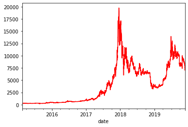

```python
btc_usd['close'].plot(color='red')
#The graph of historical bitcoin prices also confirms this view.
```

## Linear Regression

[Acemoglu2001] wish to determine whether or not differences in institutions can help to explain observed economic outcomes

In this paper,

- economic outcomes are proxied by log GDP per capita in 1995, adjusted for exchange rates - `logpgp95`
- institutional differences are proxied by an index of protection against expropriation on average over 1985-95, constructed by the [Political Risk Services Group](https://www.prsgroup.com/) - `avexpr`

These variables and other data used in the paper are available for download on Daron Acemoglu’s [webpage](https://economics.mit.edu/faculty/acemoglu/data/ajr2001)

Here's the data read in from the file

```python
import pandas as pd

df1 = pd.read_csv('https://raw.githubusercontent.com/BUSN32100/data_files/master/Acemoglu2001.csv')
df1.head()
```

|  | Unnamed: 0 | shortnam | euro1900 | excolony | avexpr | logpgp95 | cons1 | cons90 | democ00a | cons00a | extmort4 | logem4 | loghjypl | baseco |
| --- | --- | --- | --- | --- | --- | --- | --- | --- | --- | --- | --- | --- | --- | --- |
| 0 | 0 | AFG | 0.000000 | 1.0 | NaN | NaN | 1.0 | 2.0 | 1.0 | 1.0 | 93.7 | 4.540098 | NaN | NaN |
| 1 | 1 | AGO | 8.000000 | 1.0 | 5.363637 | 7.770645 | 3.0 | 3.0 | 0.0 | 1.0 | 280.0 | 5.634790 | -3.411248 | 1.0 |
| 2 | 2 | ARE | 0.000000 | 1.0 | 7.181818 | 9.804219 | NaN | NaN | NaN | NaN | NaN | NaN | NaN | NaN |
| 3 | 3 | ARG | 60.000004 | 1.0 | 6.386363 | 9.133459 | 1.0 | 6.0 | 3.0 | 3.0 | 68.9 | 4.232656 | -0.872274 | 1.0 |
| 4 | 4 | ARM | 0.000000 | 0.0 | NaN | 7.682482 | NaN | NaN | NaN | NaN | NaN | NaN | NaN | NaN |

### Question 4a

Use a scatterplot to see whether any obvious relationship exists between GDP per capita, `logpgp95` and the protection against expropriation index, `avexpr`

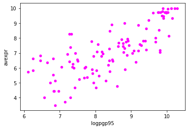

```python
#your code here
df1.plot(kind='scatter',x='logpgp95',y='avexpr',color='magenta')
plt.show()
#Looks like there is a positive relationship between GDP per capita and protection against expropriation index.
```

### Question 4b

Next construct a model regressing `logpgp95` (y) on `avexpr`(x) in `statsmodels` using the `ols` function

```python
smf.ols("logpgp95~avexpr", data=df1).fit()
```

```
<statsmodels.regression.linear_model.RegressionResultsWrapper at 0x1c28323250>
```

```python
# define your model here
ols("logpgp95~avexpr", data=df1).fit()
```

```
<statsmodels.regression.linear_model.RegressionResultsWrapper at 0x1c28300b50>
```

So far we have simply constructed our model

### Question 4c

Next fit the model, store the fitted regression model in `results`, then view the OLS regression results.

```python
# fit your model
results = ols("logpgp95~avexpr", data=df1).fit()
results
```

```
<statsmodels.regression.linear_model.RegressionResultsWrapper at 0x1c2e8884d0>
```

```python
#show the parameter estimates
print(results.params)
```

```
Intercept    4.626089
avexpr       0.531871
dtype: float64
```

## Challenge

Next calculate the average for `avexpr` and predict the `logpdp95` value for the average `avexpr`

Hint: You will need to use the `results.predict()` method. Before you use the `.predict()` method, check out the input of it. You will need to store the average value into a dictionary with `"avexpr"` as the key or Pandas Series with `"avexpr"` as the name to make predictions

```python
df1['avexpr'].mean()
```

```
7.066491380165289
```

```python
dict = {'avexpr':7.066491380165289}

results.predict(dict)
```

```
0    8.384554
dtype: float64
```